# Summary Re-write of Sierra’s Replicate Analysis Using Tidyverse

2020-08-11

```r
knitr::opts_chunk$set(echo = TRUE)
library(tidyverse); packageVersion("tidyverse")
```

```
## [1] '1.3.0'
```

```r
library(yaml); packageVersion("yaml")
```

```
## [1] '2.2.1'
```

```r
library(here); packageVersion("here")
```

```
## [1] '0.1'
```

```r
library(stringr); packageVersion("stringr")
```

```
## [1] '1.4.0'
```

# 1 Summary

Rewriting Sierra’s initial replicate analysis for evaluating within and between lab changeseq method performance.

Determine sources of variability for the CHANGE-Seq assay.

# 2 Approach

1. Samples are run through the CHANGE-Seq wet lab procedure and the library prepped smples are split between NIST & St. Jude.
2. Samples are pooled and sequenced.
3. Resulting FASTQ files are handed off to me and run through the CHANGE-Seq program.
4. Each samples produces an “identified_matched.txt” file which is what is used and described in this document.

**Downstream Bioinformatic Analysis:** 1. Loading CHANGE-Seq pipeline output (namely - “identified_matched.txt” files) 2. Annotating CHANGE-Seq data frame with sample pair/ replicate information 3. Summary/ Statistical Analysis  
1. Summary Table  
2. StJude - NIST Comparison

# 3 Data Overview

## 3.1 Samples A-F Spring 2020

| **Letter ID** | **Target Site** |
| --- | --- |
| A | CCR5_site_3 |
| B | CCR5_site_8 |
| C | TRAC_site_1 |
| D | CXCR4_site_7 |
| E | CTLA4_site_9 |
| F | AAVS1_site_14 |

**Experimental Factors** N: NIST S: St. Jude

| **Acronym** | **Wet Lab** | **Sequencing Lab** | **Bioinformatics** |
| --- | --- | --- | --- |
| NNN | NIST | NIST | NIST |
| NSN | NIST | St. Jude | NIST |
| NSS | NIST | St. Jude | St. Jude |

### 3.1.1 NN

| **Sample** | **File Name** | **File Size** |
| --- | --- | --- |
| A, read 1 | A_S1_L001_R1_001_trimmed.fq | 956.9 MB |
| A, read 2 | A_S1_L001_R2_001_trimmed.fq | 874.8 MB |
| B, read 1 | B_S2_L001_R1_001_trimmed.fq | 647.9 MB |
| B, read 2 | B_S2_L001_R2_001_trimmed.fq | 623.7 MB |
| C, read 1 | C_S3_L001_R1_001_trimmed.fq | 743.2 MB |
| C, read 2 | C_S3_L001_R2_001_trimmed.fq | 706.6 MB |
| D, read 1 | D_S4_L001_R1_001_trimmed.fq | 935.6 MB |
| D, read 2 | D_S4_L001_R2_001_trimmed.fq | 739.4 MB |
| E, read 1 | E_S5_L001_R1_001_trimmed.fq | 741.1 MB |
| E, read 2 | E_S5_L001_R2_001_trimmed.fq | 701.1 MB |
| F, read 1 | F_S6_L001_R1_001_trimmed.fq | 845.6 MB |
| F, read 2 | F_S6_L001_R2_001_trimmed.fq | 817.3 MB |
| Neg Ctrl, read 1 | neg-neg-control_S7_L001_R1_001_trimmed.fq | 858.1 MB |
| Neg Ctrl, read 2 | neg-neg-control_S7_L001_R2_001_trimmed.fq | 803 MB |

### 3.1.2 NS

| **Sample** | **File Name** | **File Size** |
| --- | --- | --- |
| A, read 1 | CRL1551_NIST_S1_R1_001.fastq | 956.9 MB |
| A, read 2 | CRL1551_NIST_S1_R2_001.fastq | 874.8 MB |
| B, read 1 | CRL1552_NIST_S2_R1_001.fastq | 647.9 MB |
| B, read 2 | CRL1552_NIST_S2_R2_001.fastq | 623.7 MB |
| C, read 1 | CRL1553_NIST_S3_R1_001.fastq | 743.2 MB |
| C, read 2 | CRL1553_NIST_S3_R2_001.fastq | 706.6 MB |
| D, read 1 | CRL1554_NIST_S4_R1_001.fastq | 935.6 MB |
| D, read 2 | CRL1554_NIST_S4_R2_001.fastq | 739.4 MB |
| E, read 1 | CRL1555_NIST_S5_R1_001.fastq | 741.1 MB |
| E, read 2 | CRL1555_NIST_S5_R2_001.fastq | 701.1 MB |
| F, read 1 | CRL1556_NIST_S6_R1_001.fastq | 845.6 MB |
| F, read 2 | CRL1556_NIST_S6_R2_001.fastq | 817.3 MB |
| Neg Ctrl, read 1 | neg-neg-CRL1557_NIST_S7_R1_001.fastq | 858.1 MB |
| Neg Ctrl, read 2 | neg-neg-CRL1557_NIST_S7_R2_001.fastq | 803 MB |

### 3.1.3 Notes on Spring2020 Samples

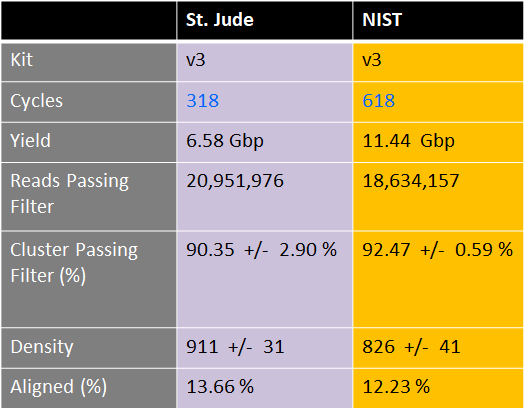

To account for extra sequencing cycles, samples sequenced at NIST were trimmed via:

```bash
seqtk trimfq -e 150
```

Both locations pooled samples according to St. Jude’s qPCR quantification values.

Samples run with CHANGE-Seq v1.2.7

*St Jude has not yet re-run our sequencing of the original A-F samples. (NNS)*

# 4 Analysis

## 4.1 Loading and Munging data

Loading CHANGE-Seq output txt files into a single data frame:

```r
## Using message = FALSE to avoid printing read_tsv message about column specifications

## List of changeseq output files
changeseq_lst <- list.files(path = here("data-raw"),
                           pattern = "identified_matched.txt",
                           include.dirs = TRUE, full.names = TRUE,
                           recursive = TRUE) %>%
    set_names(basename(.))

changeseq_df <- changeseq_lst %>%
    map_dfr(read_tsv, .id = "changeseq_run")
```

```r
unique(changeseq_df$changeseq_run)
```

```
##  [1] "NNN_A_CCR5_site_3_GM24385_identified_matched.txt"
##  [2] "NNN_B_CCR5_site_8_GM24385_identified_matched.txt"
##  [3] "NNN_C_TRAC_site_1_GM24385_identified_matched.txt"
##  [4] "NNN_D_CXCR4_site_7_GM24385_identified_matched.txt"
##  [5] "NNN_E_CTLA4_site_9_GM24385_identified_matched.txt"
##  [6] "NNN_F_AAVS1_site_14_GM24385_identified_matched.txt"
##  [7] "NSN_A_CRL1551_CCR5_site_3_GM24385_identified_matched.txt"
##  [8] "NSN_B_CRL1552_CCR5_site_8_GM24385_identified_matched.txt"
##  [9] "NSN_C_CRL1553_TRAC_site_1_GM24385_identified_matched.txt"
## [10] "NSN_D_CRL1554_CXCR4_site_7_GM24385_identified_matched.txt"
## [11] "NSN_E_CRL1555_CTLA4_site_9_GM24385_identified_matched.txt"
## [12] "NSN_F_CRL1556_AAVS1_site_14_GM24385_identified_matched.txt"
## [13] "NSS_A_CRL1551_CCR5_site_3_GM24385_identified_matched.txt"
## [14] "NSS_B_CRL1552_CCR5_site_8_GM24385_identified_matched.txt"
## [15] "NSS_C_CRL1553_TRAC_site_1_GM24385_identified_matched.txt"
## [16] "NSS_D_CRL1554_CXCR4_site_7_GM24385_identified_matched.txt"
## [17] "NSS_E_CRL1555_CTLA4_site_9_GM24385_identified_matched.txt"
## [18] "NSS_F_CRL1556_AAVS1_site_14_GM24385_identified_matched.txt"
```

Annotating using file names

```r
## This code is specific to the input file name format
changeseq_anno_df <- changeseq_df %>%
    ## adding changeseq_run col, removing ending portion of string **NOTE THAT THIS WILL NEED CHANGED WHEN LOOKING AT OTHER DNA LINES**
    mutate(changeseq_run = str_remove(changeseq_run, "_GM24385_identified_matched.txt"),
           sample = "GM24385",
           ## target site name begins 5 characters into string of changeseq_run
          target_site = str_sub(changeseq_run, 5),
          ## further edit target site col if contains the St Jude file prefixes of CRLXXXX
           target_site = str_remove(target_site,  "CRL[:digit:]*_"),
          ## lab col will contain the first 3 letter acronyms
           lab = substr(changeseq_run, 1,3)) %>%
     ## possible identifiers: NNN, NSN, NSS
     ## first = wet lab, second = sequence, third = bioinformatics
    ## take the 3 letters in lab col and split into 3 additional cols
    separate(lab, into = c("wet_lab","seq_lab","bioinf"),
           sep = c(1,2,3),
           remove = FALSE) %>%
  ## change the col contents from just letters to what they indicate
  mutate(wet_lab = if_else(wet_lab == "N", "NIST", "StJude"),
         seq_lab = if_else(seq_lab == "N", "NIST", "StJude"),
         bioinf = if_else(bioinf == "N", "NIST", "StJude"))
```

## 4.2 Summary/ Statistical Analysis

### 4.2.1 Calculating Summary Metrics

- Total Read Counts per Sample

```r
total_count_df <- changeseq_anno_df %>%
    group_by(changeseq_run, lab, target_site) %>%
    summarise(total_read_count = sum(Nuclease_Read_Count))
```

- Total on-target read count

```r
target_count_df <- changeseq_anno_df %>%
    filter(Site_Substitution_Number == 0) %>%
    rename(on_target_count = Nuclease_Read_Count) %>%
    select(changeseq_run, lab, target_site, on_target_count)
```

- Percent on-target read count (on-target read count/total read count)

```r
on_off_target_df <- left_join(total_count_df, target_count_df) %>%
    mutate(on_target_rate = on_target_count/total_read_count)
```

- Total off-target read count
- Percent off-target read count (off-target read count/total read count)

```r
summary_df <- changeseq_anno_df %>%
    ## replace NAs in Site_Substitution_Number col
    mutate(Site_Substitution_Number = if_else(is.na(Site_Substitution_Number), -1, Site_Substitution_Number),
           ## assign read count to on-target col of on-target row per sample
            on_target = if_else(Site_Substitution_Number == 0, Nuclease_Read_Count, 0),
           ## assign off-target read counts in non-on-target rows
            off_target = if_else(on_target == 0, Nuclease_Read_Count, 0),
            ## seqs with subs only = seq in Site_Sequence col only
            Substitution_Only = if_else(is.na(Site_Sequence), FALSE, TRUE),
            ## seqs with indels only = seq in Site_Sequence_Gaps_Allowed col only
            Indel_Only = if_else(is.na(Site_Sequence_Gaps_Allowed), TRUE, FALSE),
            ## seqs with two possible reps = seq in both cols
            Sub_or_Indel = if_else(is.na(Substitution_Only || Indel_Only), FALSE, TRUE))
```

- Number of sequences with substitutions only
- Number sequences with indels only
- Number of sequences with two possible representations (substitutions or indels)

```r
## create df to plot off-target ratio
off_target_ratio <- summary_df %>%
    group_by(changeseq_run, lab, target_site) %>%
    summarise(total_count = sum(Nuclease_Read_Count),
              total_on_target = sum(on_target),
              total_off_target = sum(off_target),
              off_target_ratio = total_off_target/total_count)
## create df to plot alignment of off-target seq resolution details
off_target_seq_align_df <- summary_df%>%
    group_by(changeseq_run, lab, target_site) %>%
    summarise(total_substitution_only_seqs = sum(Substitution_Only),
              total_indels_only = sum(Indel_Only),
              total_sub_or_indel = sum(Sub_or_Indel))
```

```r
## create df of all off-target rows sorted by decreasing read count value
off_target_df <- summary_df %>%
    mutate(Substitution_Only = if_else(is.na(Site_Sequence), FALSE, TRUE),
           on_target = if_else(Site_Substitution_Number == 0, Nuclease_Read_Count, 0)) %>%
    filter(Substitution_Only == TRUE) %>%
        arrange(-Nuclease_Read_Count)

## take the top 25% of the off-target df - based on read count value
top_quarter_off_target_df <- off_target_df %>%
    ## Use top_frac to get the top 25% - use group_by to capture within run or site analysis
      top_frac(0.25, wt = Nuclease_Read_Count) %>%
  group_by(changeseq_run, lab, target_site) %>%
  summarise(top_quarter_offtarget_readcount = sum(Nuclease_Read_Count))
```

- On-target to most prevalent off-target read (on-target read count/off-target read with largest read count)

```r
## create df to plot ratio between on-target read count and most prevalent off-target read count per sample
on_top_off_df <- summary_df %>%
    mutate(Site_Substitution_Number = if_else(is.na(Site_Substitution_Number), -1, Site_Substitution_Number),
            on_target = if_else(Site_Substitution_Number == 0, Nuclease_Read_Count, 0),
           off_target = if_else(on_target == 0, Nuclease_Read_Count, 0)) %>%
    group_by(changeseq_run, lab, target_site) %>%
    summarise(on_target_count = max(on_target),
              off_target_max = max(off_target)) %>%
    mutate(on_off_max_ratio = on_target_count/ off_target_max)
```

- Read count for seqs w/ 1 substitution from target sequence
- Read count for seqs w/ 2 substitutions from target sequence
- Read count for seqs w/ 3 substitutions from target sequence
- Read count for seqs w/ 4 substitutions from target sequence
- Read count for seqs w/ 5 substitutions from target sequence
- Read count for seqs w/ 6 substitutions from target sequence

```r
## create df to plot the binned read counts of off-target substitution numbers
substitution_count_df <- summary_df %>%
    mutate(Substitution_Only = if_else(is.na(Site_Sequence), FALSE, TRUE)) %>%
    filter(Substitution_Only == TRUE,
           Site_Substitution_Number > 0) %>%
    group_by(changeseq_run, lab, target_site, Site_Substitution_Number) %>%
    summarise(substitution_read_count = sum(Nuclease_Read_Count))
```

### 4.2.2 Summary Metric Analysis

#### 4.2.2.1 Plots

- Bar Plot of Total Read Counts per Sample

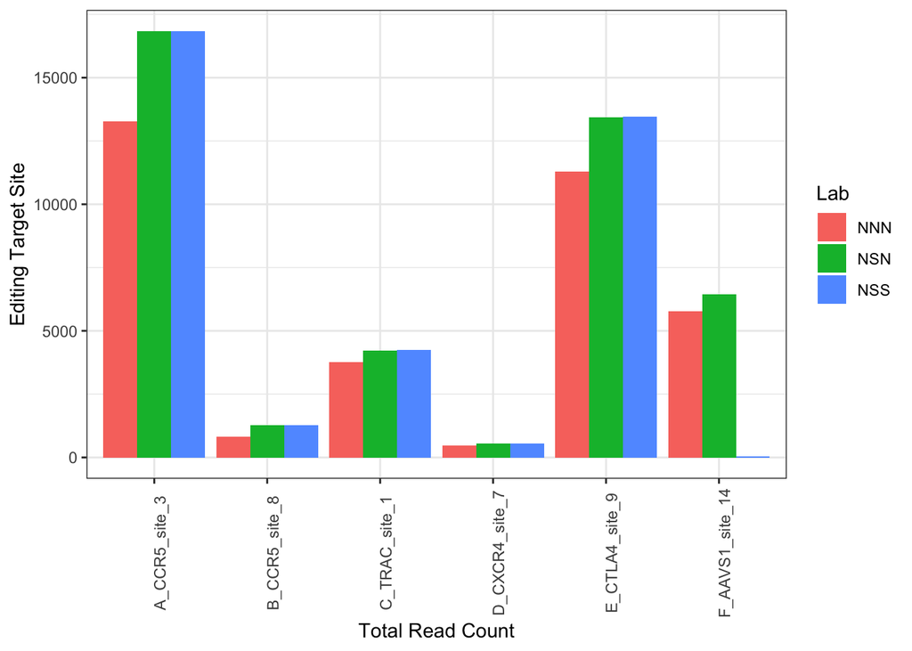

```r
ggplot(total_count_df) +
    geom_bar(aes(x = target_site, y = total_read_count, fill = lab),
             position = "dodge", stat = "identity") +
    theme_bw() +
    theme(axis.text.x = element_text(angle = 90)) +
    labs(x = "Total Read Count", y = "Editing Target Site",
         fill = "Lab")
```

Sample F for NSS has a drastically lower total read count when compared to NNN and NSN. St. Jude’s CHANGE-Seq manifest file was pointing to sample E’s read fastq files for sample F. Regarding the sequencing at NIST vs. the sequencing at St. Jude, our sequencing runs have consistently lower total read counts. Potential sources of variability: Sequencing and Person running bioinformatics.

- Bar Plot of On-Target Read Counts per Sample

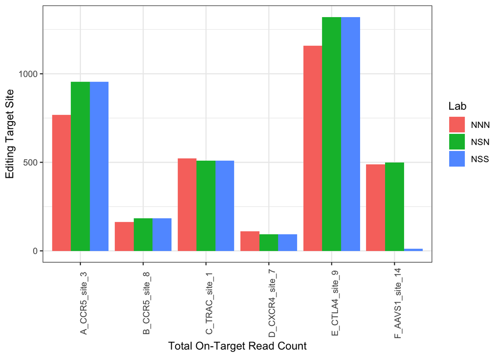

```r
ggplot(target_count_df) +
    geom_bar(aes(x = target_site, y = on_target_count, fill = lab),
             position = "dodge", stat = "identity") +
    theme_bw() +
    theme(axis.text.x = element_text(angle = 90)) +
    labs(x = "Total On-Target Read Count", y = "Editing Target Site",
         fill = "Lab")
```

Consistent pattern (disregarding sample F from St. Jude’s sequenced and bioinformatics) of similar values between my run and St. Jude’s run of CHANGE-Seq on their sequenced samples and NIST with lower values for reads except for sample C and D where our on-target read count is just slightly more than that of St. Jude’s sequenced samples.

*Scatter Plot of On-Target Read Count/Total Read Count

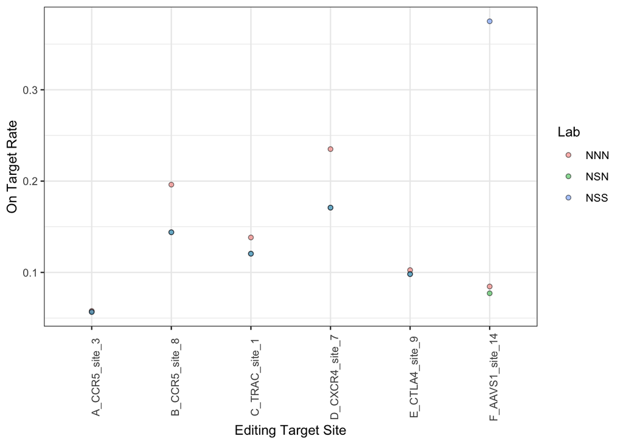

```r
ggplot(on_off_target_df) +
    geom_point(aes(x = target_site, y = on_target_rate, fill = lab),
               shape = 21, alpha = 0.5) +
    theme_bw() +
    theme(axis.text.x = element_text(angle = 90)) +
        labs(x = "Editing Target Site", y = "On Target Rate",
         fill = "Lab")
```

On-target rates for sample A, E, and F are nearly matched and variance for samples B, C, and D is observed. NIST-sequenced samples are slightly higher.

*Scatter Plot of Off-Target Read Count/Total Read Count

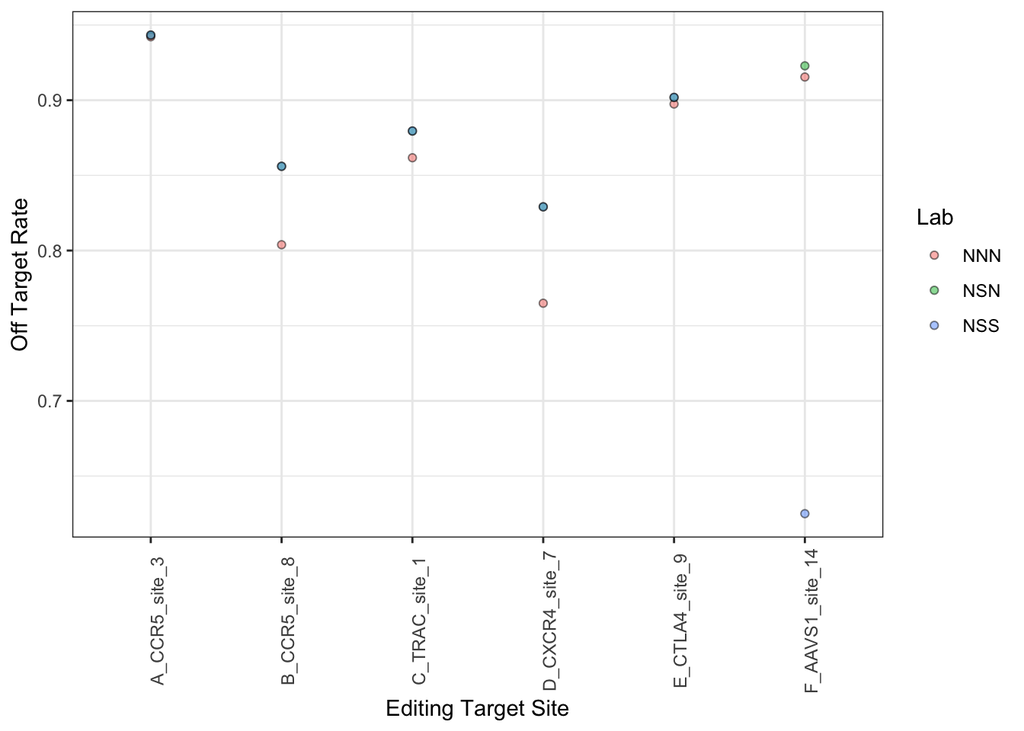

```r
ggplot(off_target_ratio) +
    geom_point(aes(x = target_site, y = off_target_ratio, fill = lab),
               shape = 21, alpha = 0.5) +
    theme_bw() +
    theme(axis.text.x = element_text(angle = 90)) +
        labs(x = "Editing Target Site", y = "Off Target Rate",
         fill = "Lab")
```

The rates of the off-target sequences are generally all higher than that of the on-target rates. Like the on-target rates, samples A, E, and F are similar in value. Samples B, C, and D have variance with the inverse of the above - the off-target rates are higher for the St. Jude-sequenced samples than that of the NIST-sequenced samples.

- Paneled bar plot showing off-target sequence alignment details

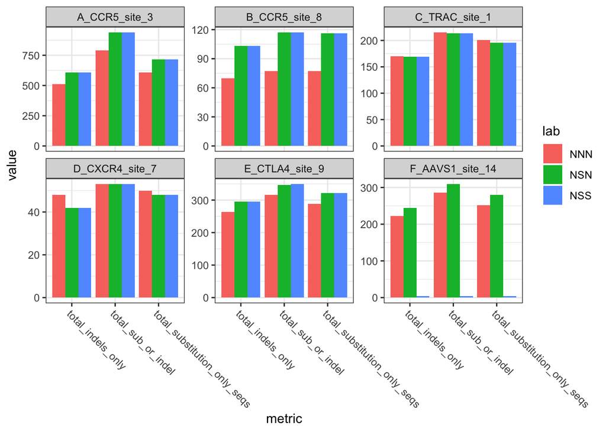

```r
off_target_seq_align_df %>%
    ## First make the table long
    gather(key = "metric", value = "value", -changeseq_run, -lab, -target_site) %>%
    ggplot() +
    geom_bar(aes(x = metric,
                 y = value,
                 fill = lab),
             position = "dodge",
             stat = "identity"
             ) +
    ## Split plot by summary metric
    facet_wrap(~target_site, scales = "free_y") +
    theme_bw() +
    theme(axis.text.x = element_text(angle = -45, hjust = 0))
```

The off-target sequences are aligned to the target sequence. These are binned in the following manner: in order to align properly to the target sequence, the off-target sequence could be resolve with substitutions (and assigned a substitution number), gaps (insertions or deletions) or by both possibilities. Here, I have binned them accordingly. As before, no major differences are observed between the samples sequenced at St. Jude but run through the CHANGE-Seq bioinformatics pipeline by me and St. Jude, however, variance is observed between the samples sequenced at NIST vs. St. Jude. For samples A and B, NIST-sequenced off-target reads are overall in lower numbers as compared to St. Jude.

- Bar plot of top 25% off-target read counts

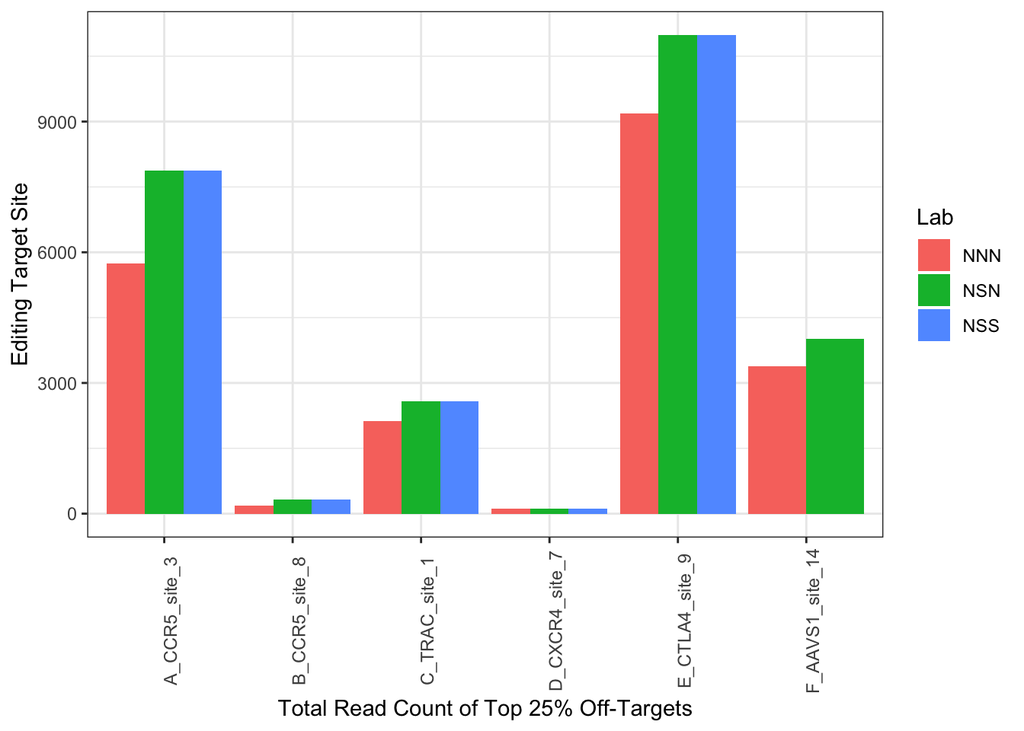

```r
ggplot(top_quarter_off_target_df) +
    geom_bar(aes(x = target_site, y = top_quarter_offtarget_readcount, fill = lab),
             position = "dodge", stat = "identity") +
    theme_bw() +
    theme(axis.text.x = element_text(angle = 90)) +
    labs(x = "Total Read Count of Top 25% Off-Targets", y = "Editing Target Site",
         fill = "Lab")
```

- Scatter plot showing the ratio of on-target read counts to the off-target sequence with the highest read count

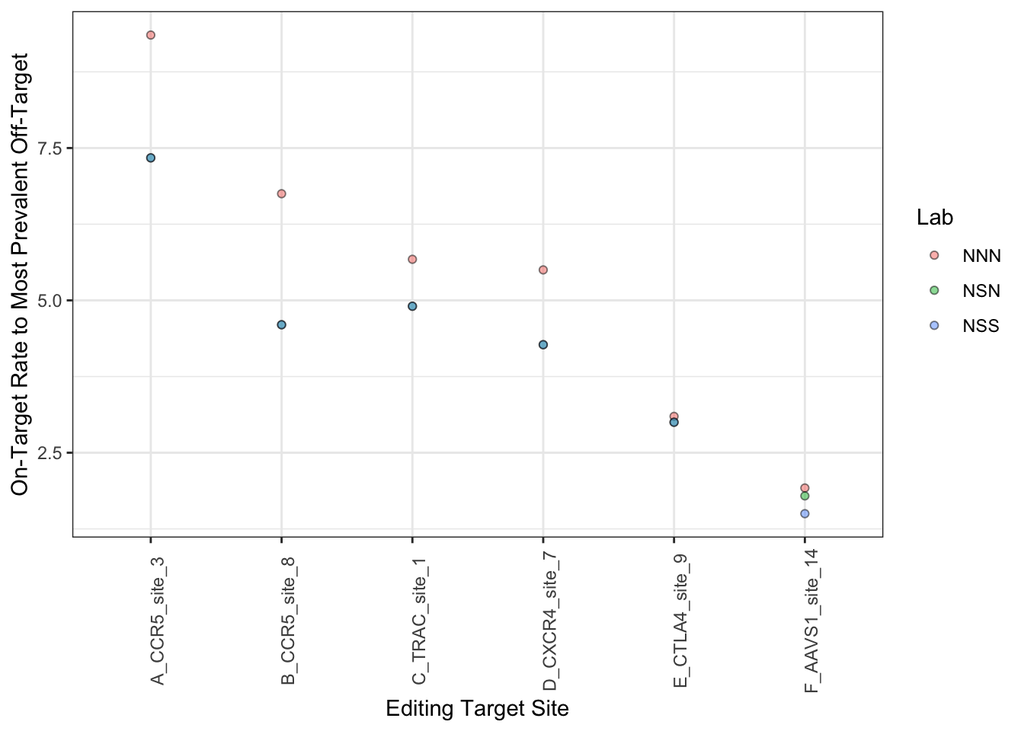

```r
ggplot(on_top_off_df) +
    geom_point(aes(x = target_site, y = on_off_max_ratio, fill = lab),
               shape = 21, alpha = 0.5) +
    theme_bw() +
    theme(axis.text.x = element_text(angle = 90)) +
        labs(x = "Editing Target Site", y = "On-Target Rate to Most Prevalent Off-Target",
         fill = "Lab")
```

As seen with the on-target rate considering total read counts, NIST has higher rates than St. Jude-sequenced samples.

- Plot of read counts per substitution number for each sample

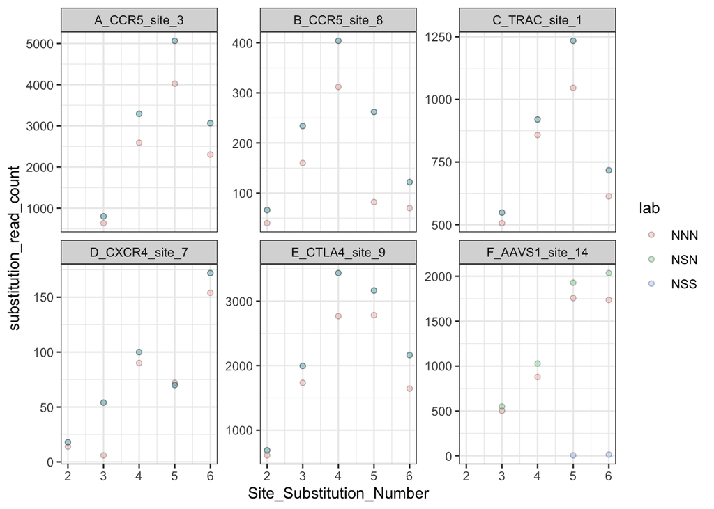

```r
substitution_count_df %>%
  ggplot() +
  geom_point(aes(x = Site_Substitution_Number, y = substitution_read_count, fill = lab),
             shape = 21, alpha = 0.25) +
  facet_wrap(~target_site, scales = "free_y") +
  theme_bw()
```